# Lecture 3 Notebook

Duncan Callaway September 5 2019

This lecture is a review of variable types and an introduction to the pandas library within python.

My objective is to review enough of the basics to give people a clear sense of what a pandas data frame is and what it can contain.

## Pandas references

(taken from DS100)

Introductory:

- [Getting started with Python for research](https://github.com/TiesdeKok/LearnPythonforResearch), a gentle introduction to Python in data-intensive research.
- [A Whirlwind Tour of Python](https://jakevdp.github.io/WhirlwindTourOfPython/index.html), by Jake VanderPlas, another quick Python intro (with notebooks).

Core Pandas/Data Science books:

- [The Python Data Science Handbook](https://jakevdp.github.io/PythonDataScienceHandbook/), by Jake VanderPlas.
- [Python for Data Analysis, 2nd Edition](http://proquest.safaribooksonline.com/book/programming/python/9781491957653), by Wes McKinney, creator of Pandas. [Companion Notebooks](https://github.com/wesm/pydata-book)
- [Effective Pandas](https://github.com/TomAugspurger/effective-pandas), a book by Tom Augspurger, core Pandas developer.

Complementary resources:

- [An introduction to "Data Science"](https://github.com/stefanv/ds_intro), a collection of Notebooks by BIDS' [Stéfan Van der Walt](https://bids.berkeley.edu/people/st%C3%A9fan-van-der-walt).
- [Effective Computation in Physics](http://proquest.safaribooksonline.com/book/physics/9781491901564), by Kathryn D. Huff; Anthony Scopatz. [Notebooks to accompany the book](https://github.com/physics-codes/seminar). Don't be fooled by the title, it's a great book on modern computational practices with very little that's physics-specific.

## A few more shortcuts

`esc` --> command mode for cell

`enter` --> edit mode for cell

`shift-enter` --> run cell and select next cell

`ctrl-enter` --> run cell and keep it selected

in command mode, `a` creates a new cell above

in command mode, `b` creates a new cell below

in command mode, `dd` deletes cell

in command mode, `m` turns cell into markdown

in command mode, `y` turns cell to code

in command mode, `h` shows keyboard shortcuts

`shift-tab` gives information on a function or method

`tab` gives options to add a method or function to an object.

## Object, method, function?

These phrases come up repeatedly in python.

Q: What are they?

Go [here for more](https://www.geeksforgeeks.org/difference-method-function-python/)

1. Object: virtually anything with attributes in python.
   1. Objects usually belong to classes and have attributes
   2. For example an object might belong to a bike class. The attributes of the class would be material, wheel size, number of gears, etc.
2. Method: A function associated with an object. a. for example `object.method` applies the method to the object.
3. Function: performs an action using some set of input parameters. b. for example `function(object)` applies the function to the object.

We'll talk about each of these in class today.

## Basic data, or variable, types

Q: what are some variable types native to Python?

1. `string`
2. `numbers`
   1. `int`
   2. `float`
3. `bool`

**Strings**

```python
name = 'Imogen'
type(name)
```

```
str
```

```python
name[2]
```

```
'o'
```

An interesting note about strings: though we can index their contents, they are *immutable*, meaning you can't change individual elements. Instead you need to do a wholesale reassignment.

```python
name[4] = 'y'
```

```
---------------------------------------------------------------------------
TypeError                                 Traceback (most recent call last)
<ipython-input-6-b6910fa71c71> in <module>()
----> 1 name[4] = 'y'

TypeError: 'str' object does not support item assignment
```

```python
name = name[0:4] + 'y' + name[5]
name
```

```
'Imogyn'
```

**Floats**

```python
x = 0.34
type(x)
```

```
float
```

**Int**

```python
i = 1
type(i)
```

```
int
```

**Boolean**

```python
ans = True
type(ans)
```

```
bool
```

Note that Python is 'dynamically typed' meaning it assigns a variable a type based on what you set it equal to.

You don't need to define the type ahead of time.

But note that Python is also 'strongly typed' meaning that once the variable has a type, you have to work hard to reassign it.

## Data structures or "containers"

Q: what are some data structures native to Python?

1. `dict`
2. `list`
3. `tuple`
4. `set`

Let's explore these a little further.

### Lists

```python
squares = [1, 5, 9, 16, 25] # do this in lecture
squares
```

```
[1, 5, 9, 16, 25]
```

We can index elements with the usual process:

```python
print(squares[0]) # do this in lecture; zero is the first element
print(squares[-1]) # do this in lecture; -1 gives the last
print(squares[2:]) # do this in lecture; you can slice...
```

```
1
25
[9, 16, 25]
```

What does "mutable" mean?

...that you can change individual entries of the data structure.

Lists are mutable:

```python
squares[1] = 4
squares
```

```
[1, 4, 9, 16, 25]
```

That's better!

We can also append:

```python
squares.append(6**2)
squares
```

```
[1, 4, 9, 16, 25, 36]
```

We can append lists this way too:

```python
squares = squares + [49]
squares
```

```
[1, 4, 9, 16, 25, 36, 49]
```

Finally, we can nest lists

```python
x = [1,2,3]
y = [4,6]
```

```python
A = [x,y]
A
```

```
[[1, 2, 3], [4, 6]]
```

Note that the number of elements in the two lists within the list did not need to be equal.

Note also that we can also assign different variable types to the nested list:

```python
a = ['abc', 'def']
```

```python
A = [x,a]
A
```

```
[[1, 2, 3], ['abc', 'def']]
```

Careful though, it's tough to index these things.

Think about how you might get the entry 'def' from the list, by integer indexes.

```python
A[1,1]
```

```
---------------------------------------------------------------------------
TypeError                                 Traceback (most recent call last)
<ipython-input-20-80a1a5f00f0b> in <module>()
----> 1 A[1,1]

TypeError: list indices must be integers or slices, not tuple
```

That didn't work! (We have to wait for numpy and pandas to be able to do that.)

```python
A[1][1]
```

```
'def'
```

Note, pandas data frames are a lot like lists in this way. You first index which "sublist" you want, then you index into elements of that. Numpy arrays (as we'll see) are much easier to index. Frankly, the indexing with pandas is pretty annoying, but there are some workarounds that we'll discuss.

### Tuples

Tuples are like lists -- they hold multiple elements and you can index them. The key difference is that they are *immutable*

```python
B = (1,2,3)
B
```

```
(1, 2, 3)
```

```python
B[1]
```

```
2
```

```python
B[1] = 3
```

```
---------------------------------------------------------------------------
TypeError                                 Traceback (most recent call last)
<ipython-input-4-9bc40c1a86bc> in <module>()
----> 1 B[1] = 3

TypeError: 'tuple' object does not support item assignment
```

Changing and individual element throws an error.

So why bother with tuples?

1. They are harder to work with, but
2. They prevent you from doing things you don't want to, and
3. They are more memory-efficient.

### Sets

Whereas lists are defined with square brackets, sets use curlies:

```python
basket = {'apple', 'orange', 'apple', 'pear', 'orange', 'banana'}
```

What happened there?

...I wrote orange and apple twice. Let's look at the set:

```python
print(basket)
```

```
{'apple', 'orange', 'pear', 'banana'}
```

Pretty smart -- no duplicates!

What might you do if you have a variable called basket but you don't know what's in it?

Now we can query the set for membership:

```python
'orange' in basket
```

```
True
```

```python
'kiwi' in basket
```

```
False
```

### Dict

Now let's talk about dicts. We are inching closer to the kind of structure we have in a pandas data frame.

Dicts associate one value with another.

```python
cars = {'Prius':'Toyota', 'Volt':'Chevy', 'Model 3': 'Tesla'}
cars
```

```
{'Model 3': 'Tesla', 'Prius': 'Toyota', 'Volt': 'Chevy'}
```

```python
cars['Prius']
```

```
'Toyota'
```

In this case

1. 'Prius' is the **key** of the dict.
2. 'Toyota' is the associated **value**.

We can add new entries very easily:

```python
cars['Leaf'] = 'Nissan'
```

```python
cars
```

```
{'Leaf': 'Nissan', 'Model 3': 'Tesla', 'Prius': 'Toyota', 'Volt': 'Chevy'}
```

Important note here: the dict does not store entries in any particular order -- you rely on the key to pull data out.

## Numpy

Before moving into pandas, let's do a quick review of numpy. A numpy array is a grid of elements *of the same data type*. (Pandas is like numpy but handles different data types.) The beauty of numpy, like matlab, is that you don't need to specify what sort of data type you're working with -- it will guess for you.

```python
import numpy as np
a = np.array([[1,2,3], [4,5,6]])
a
```

```
array([[1, 2, 3],
       [4, 5, 6]])
```

That's a numpy array.

Q: What have we seen before that looks a lot like this?

A: a nested list.

A big difference, though, is that we can index numpy arrays more cleanly can we can lists:

```python
a[1,1]
```

```
5
```

What is the first index entry calling? If you're not sure, play around with `a` to see if you can figure it out.

Answer: The row.

What happens when we try to add a different data type to the array?

```python
a[1,1] = 'g'
a
```

```
---------------------------------------------------------------------------
ValueError                                Traceback (most recent call last)
<ipython-input-32-39311fbdb845> in <module>()
----> 1 a[1,1] = 'g'
      2 a

ValueError: invalid literal for int() with base 10: 'g'
```

We can't make the assignment. However if we do it in the original definition, we can

```python
a = np.array([[1,2,3], [4,5,'g']])
a
```

```
array([['1', '2', '3'],
       ['4', '5', 'g']], dtype='<U21')
```

What happens if we try to do mathematical operations on this type?

```python
a[1,0]+1
```

```
---------------------------------------------------------------------------
TypeError                                 Traceback (most recent call last)
<ipython-input-34-678a4915e8e5> in <module>()
----> 1 a[1,0]+1

TypeError: must be str, not int
```

Doesn't work. Even though the specific entry was *originally* numeric, it stored it as a str to make it consistent with storing the letter 'g'.

**Ok. What's a slice?**

It's a portion of the array that we call with expressions involving a colon `:` in the index locations.

```python
a[0:1, 0:2]
```

```
array([['1', '2']], dtype='<U21')
```

Perhaps you remember that the indexing is not *inclusive* meaning it does not include data associated with the end index. To get the last value you can just leave the position in the slice syntax empty:

```python
a[1:, 1:]
```

```
array([['5', 'g']], dtype='<U21')
```

You can also put a number after a *second* colon in the slice syntax. Negative numbers slice backwards.

```python
a[:,-1::-1]
```

```
array([['3', '2', '1'],
       ['g', '5', '4']], dtype='<U21')
```

```python
a[:,0::2]
```

```
array([['1', '3'],
       ['4', 'g']], dtype='<U21')
```

**Question**: Is python indexing inclusive?  
**Answer**: No, it skips the number at the end of the slice.

So how do I include entries at the ends?

If we want to get all the way to the end of the array, just drop the second entry in the slice:

```python
a[:, -1::-1]
```

```
array([['3', '2', '1'],
       ['g', '5', '4']], dtype='<U21')
```

## Pandas!

Ok, finally we're here.

In Data8 you used the `tables` library to organize and manipulate data. I've not used tables but it has been described to me as a 'light' version of pandas. So this will be somewhat familiar to you.

Pandas has several features that make it immediately better than numpy for organizing data.

1. You can have different data types (string, int, float) in each column
2. You can label columns (headers)
3. You can label rows (index)

We call the data structure that holds all these things together a **data frame**

**Ambiguity alert**: up to now we've talked about indexing to access individual elements of a data structure. The index in pandas has a slightly more specific meaning, in that it references the rows of the data frame. Pandas documentation talks about "location" or "position" in place using "index" as we did with the other data structures. I'll try my best to disambiguate, but also rely on context to clarify the meaning of the terms.

At its core, the data frame structure is what draws us to use pandas. But it also has a bunch of great built-in functions you can use to manipulate data once it is loaded in.

```python
import pandas as pd
```

I'm going to define a simple data frame in a way that you can see the connections to existing Python data types and structures.

First let's define a dict of fruit information:

```python
fruit_info_dict = {'fruit':['apple','banana','orange','raspberry'],
                  'color':['red','yellow','orange','pink'],
                  'weight':[120,150,250,15]}
fruit_info_dict
```

```
{'color': ['red', 'yellow', 'orange', 'pink'],
 'fruit': ['apple', 'banana', 'orange', 'raspberry'],
 'weight': [120, 150, 250, 15]}
```

```python
fruit_info_df = pd.DataFrame(
    data={'fruit':['apple','banana','orange','raspberry'],
                  'color':['red','yellow','orange','pink'],
                  'weight':[120,150,250,15]
         })
fruit_info_df
```

|  | fruit | color | weight |
| --- | --- | --- | --- |
| 0 | apple | red | 120 |
| 1 | banana | yellow | 150 |
| 2 | orange | orange | 250 |
| 3 | raspberry | pink | 15 |

Some notes:

1. You can see that we put the data inside curly brackets much like we do in a dict.
   1. We defined it as if fruit, color and weight are keys.
   2. In fact, we'll be calling these column names.
2. The pandas data structure is called the data frame.

```python
type(fruit_info_df)
```

```
pandas.core.frame.DataFrame
```

We can call the values associated with each column name (like the dict key) in much the same way that we did with the dict:

```python
fruit_info_dict['color']
```

```
['red', 'yellow', 'orange', 'pink']
```

```python
fruit_info_df['color']
```

```
0       red
1    yellow
2    orange
3      pink
Name: color, dtype: object
```

But notice above in the dataframe we don't just have a list of colors. Instead we have something called a **series**. This is a pandas object that is analogous to a numpy series.

```python
type(fruit_info_df['color'])
```

```
pandas.core.series.Series
```

The series differs from the list in at least one important way: It has numbers directly associated with it that we call the index. (The left column of the Series.)

Note that in the above, the index is just numeric. But as we'll see, we can make it whatever we want. This makes the data frame much more flexible than a list -- we can call elements from a sensical index, rather than just a number.

We can also call columns from the data frame as follows:

```python
fruit_info_df.color
```

```
0       red
1    yellow
2    orange
3      pink
Name: color, dtype: object
```

But as we'll see soon, there are alternative ways to get access to the elements of the data frame (`.loc` and `.iloc`) that enable us to work with the frame more as we would a numpy array.

Let me show a quick example of the problems we run into if we *don't* use `.loc` or `.iloc`.

We *can* slice the frame as you might think:

```python
fruit_info_df[0:1]
```

|  | fruit | color | weight |
| --- | --- | --- | --- |
| 0 | apple | red | 120 |

But we *can't* slice on columns and rows:

```python
fruit_info_df[0:1,0:1]
```

```
---------------------------------------------------------------------------
TypeError                                 Traceback (most recent call last)
<ipython-input-52-74c89770efaa> in <module>()
----> 1 fruit_info_df[0:1,0:1]

/anaconda3/lib/python3.6/site-packages/pandas/core/frame.py in __getitem__(self, key)
   2686             return self._getitem_multilevel(key)
   2687         else:
-> 2688             return self._getitem_column(key)
   2689
   2690     def _getitem_column(self, key):

/anaconda3/lib/python3.6/site-packages/pandas/core/frame.py in _getitem_column(self, key)
   2693         # get column
   2694         if self.columns.is_unique:
-> 2695             return self._get_item_cache(key)
   2696
   2697         # duplicate columns & possible reduce dimensionality

/anaconda3/lib/python3.6/site-packages/pandas/core/generic.py in _get_item_cache(self, item)
   2485         """Return the cached item, item represents a label indexer."""
   2486         cache = self._item_cache
-> 2487         res = cache.get(item)
   2488         if res is None:
   2489             values = self._data.get(item)

TypeError: unhashable type: 'slice'
```

Nor can we index individual entries:

```python
fruit_info_df[1,1]
```

[output not shown]

[output cut: 12 more lines]

[output not shown]

If we want individual entries instead we have to first call the column, then the row:

```python
fruit_info_df['color'][1]
```

```
'yellow'
```

...But that's a little annoying, since the numpy (and most other) conventions is to first reference the row, then the column.

Also, there is no way to slice on columns:

```python
fruit_info_df['color':'weight']
```

```
---------------------------------------------------------------------------
TypeError                                 Traceback (most recent call last)
<ipython-input-55-154bca370580> in <module>()
----> 1 fruit_info_df['color':'weight']

/anaconda3/lib/python3.6/site-packages/pandas/core/frame.py in __getitem__(self, key)
   2674
   2675         # see if we can slice the rows
-> 2676         indexer = convert_to_index_sliceable(self, key)
   2677         if indexer is not None:
   2678             return self._getitem_slice(indexer)

/anaconda3/lib/python3.6/site-packages/pandas/core/indexing.py in convert_to_index_sliceable(obj, key)
   2324     idx = obj.index
   2325     if isinstance(key, slice):
-> 2326         return idx._convert_slice_indexer(key, kind='getitem')
   2327
   2328     elif isinstance(key, compat.string_types):

/anaconda3/lib/python3.6/site-packages/pandas/core/indexes/base.py in _convert_slice_indexer(self, key, kind)
   1724             """
   1725             if self.is_integer() or is_index_slice:
-> 1726                 return slice(self._validate_indexer('slice', key.start, kind),
   1727                              self._validate_indexer('slice', key.stop, kind),
   1728                              self._validate_indexer('slice', key.step, kind))

/anaconda3/lib/python3.6/site-packages/pandas/core/indexes/base.py in _validate_indexer(self, form, key, kind)
   4143             pass
   4144         elif kind in ['iloc', 'getitem']:
-> 4145             self._invalid_indexer(form, key)
   4146         return key
   4147

/anaconda3/lib/python3.6/site-packages/pandas/core/indexes/base.py in _invalid_indexer(self, form, key)
   1861                         "indexers [{key}] of {kind}".format(
   1862                             form=form, klass=type(self), key=key,
-> 1863                             kind=type(key)))
   1864
   1865     def get_duplicates(self):

TypeError: cannot do slice indexing on <class 'pandas.core.indexes.range.RangeIndex'> with these indexers [color] of <class 'str'>
```

**Stretch Break!**

### Anatomy of the data frame.

Let's talk a little about the anatomy of the data frame.

[figure not shown]

We have the following important attributes:

1. Rows
2. Columns
3. Index
4. Column names

The "index" can be numeric, but as we'll see we can also make the indices strings.

### Pandas and the CAISO data.

Let's see what's in the current directory. In macos, I type:

```python
!ls
```

```
03 Pandas.pptx
CAISO_2017to2018.csv
Duncan's Lecture 3 in class workbook.ipynb
Lecture 3 Notebook.ipynb
Lecture 3 Notebook.pdf
My Lecture 3 in class workbook.ipynb
Untitled.ipynb
dataframe_anatomy.png
```

But if someone picked up my ipynb and ran it on windows, they'd get an error.

Instead we can use the `os` library:

```python
import os
os.listdir()
```

```
['03 Pandas.pptx',
 'Untitled.ipynb',
 'dataframe_anatomy.png',
 'Lecture 3 Notebook.pdf',
 'My Lecture 3 in class workbook.ipynb',
 'Lecture 3 Notebook.ipynb',
 '.ipynb_checkpoints',
 "Duncan's Lecture 3 in class workbook.ipynb",
 'CAISO_2017to2018.csv']
```

I've already downloaded a file, "CAISO_2017_to_2018.csv", that has one year of renewables production data from CAISO.

Let's load that in as a dataframe and take a look at it.

The simplest command is `pd.read_csv`

```python
caiso_data = pd.read_csv('CAISO_2017to2018.csv')
```

Now we can look at the top of the dataframe using the .head method.

Note that you need to put parentheses on the end of the call, otherwise python returns the head "object" in a rather ugly form.

```python
caiso_data.head()
```

|  | Unnamed: 0 | GEOTHERMAL | BIOMASS | BIOGAS | SMALL HYDRO | WIND TOTAL | SOLAR PV | SOLAR THERMAL |
| --- | --- | --- | --- | --- | --- | --- | --- | --- |
| 0 | 2017-08-29 00:00:00 | 1181 | 340 | 156 | 324 | 1551 | 0 | 0 |
| 1 | 2017-08-29 01:00:00 | 1182 | 338 | 156 | 326 | 1556 | 0 | 0 |
| 2 | 2017-08-29 02:00:00 | 1183 | 337 | 156 | 337 | 1325 | 0 | 0 |
| 3 | 2017-08-29 03:00:00 | 1185 | 339 | 156 | 313 | 1158 | 0 | 0 |
| 4 | 2017-08-29 04:00:00 | 1190 | 344 | 156 | 320 | 1209 | 0 | 0 |

Pandas loaded the date and time in as a column and put its own row numbers on the data frame.

As an alternative we can actually make the row labels *equal* to whatever column of data we'd like. We'll come back to the notion of the index a little later, but for now let's just reload with the date-time as the index:

```python
caiso_data = pd.read_csv('CAISO_2017to2018.csv', index_col=0)
caiso_data.head()
```

|  | GEOTHERMAL | BIOMASS | BIOGAS | SMALL HYDRO | WIND TOTAL | SOLAR PV | SOLAR THERMAL |
| --- | --- | --- | --- | --- | --- | --- | --- |
| 2017-08-29 00:00:00 | 1181 | 340 | 156 | 324 | 1551 | 0 | 0 |
| 2017-08-29 01:00:00 | 1182 | 338 | 156 | 326 | 1556 | 0 | 0 |
| 2017-08-29 02:00:00 | 1183 | 337 | 156 | 337 | 1325 | 0 | 0 |
| 2017-08-29 03:00:00 | 1185 | 339 | 156 | 313 | 1158 | 0 | 0 |
| 2017-08-29 04:00:00 | 1190 | 344 | 156 | 320 | 1209 | 0 | 0 |

Ok, that looks a little better for now.

As you can see, all the data are the same type of numeric value -- MWh.

In these cases, sometimes it's natural to "stack" the data.

We could do the stacking with a pandas command, `.stack`, but it requires a little more massaging than I want to get into right now. So I've saved a stacked version of the data as a csv:

```python
caiso_data_stack = pd.read_csv('CAISO_2017to2018_stack.csv', index_col=0)
caiso_data_stack.head()
```

|  | Source | MWh |
| --- | --- | --- |
| 2017-08-29 00:00:00 | GEOTHERMAL | 1181 |
| 2017-08-29 00:00:00 | BIOMASS | 340 |
| 2017-08-29 00:00:00 | BIOGAS | 156 |
| 2017-08-29 00:00:00 | SMALL HYDRO | 324 |
| 2017-08-29 00:00:00 | WIND TOTAL | 1551 |

You can see now that the category of generation has become a variable rather than a column name.

There are lots of ways to stack data, as you might guess.

Let's work with a few things to explore the data frame.

We've already learned about `.head` but we can use it slightly differently:

```python
caiso_data.head(2) # the number in the parens tells pandas how many rows
```

|  | GEOTHERMAL | BIOMASS | BIOGAS | SMALL HYDRO | WIND TOTAL | SOLAR PV | SOLAR THERMAL |
| --- | --- | --- | --- | --- | --- | --- | --- |
| 2017-08-29 00:00:00 | 1181 | 340 | 156 | 324 | 1551 | 0 | 0 |
| 2017-08-29 01:00:00 | 1182 | 338 | 156 | 326 | 1556 | 0 | 0 |

We can also look at the tail!

```python
caiso_data.tail()
```

|  | GEOTHERMAL | BIOMASS | BIOGAS | SMALL HYDRO | WIND TOTAL | SOLAR PV | SOLAR THERMAL |
| --- | --- | --- | --- | --- | --- | --- | --- |
| 2018-08-28 19:00:00 | 962 | 332 | 236 | 581 | 3300 | 70 | 24 |
| 2018-08-28 20:00:00 | 967 | 336 | 234 | 547 | 3468 | 0 | 17 |
| 2018-08-28 21:00:00 | 972 | 336 | 233 | 502 | 3310 | 0 | 17 |
| 2018-08-28 22:00:00 | 975 | 333 | 234 | 361 | 3068 | 0 | 0 |
| 2018-08-28 23:00:00 | 977 | 333 | 235 | 262 | 2921 | 0 | 0 |

What's the shape of the frame?

```python
print('Unstacked shape is ',caiso_data.shape)
print('Stacked shape is ',caiso_data_stack.shape)
```

```
Unstacked shape is  (8760, 7)
Stacked shape is  (61320, 1)
```

The `.shape` method returns a tuple -- number of rows and number of columns.

What about the total number of entries? Use the `.size` method:

```python
print('Unstacked size is ',caiso_data.size)
print('Stacked size is ',caiso_data_stack.size)
```

```
Unstacked size is  61320
Stacked size is  61320
```

Both shape and size commands return information about how much data is in the frame. What's the difference?

We can also look at "summary statistics" of the numeric values of the frame:

```python
caiso_data.describe()
```

|  | GEOTHERMAL | BIOMASS | BIOGAS | SMALL HYDRO | WIND TOTAL | SOLAR PV | SOLAR THERMAL |
| --- | --- | --- | --- | --- | --- | --- | --- |
| count | 8760.000000 | 8760.000000 | 8760.000000 | 8760.000000 | 8760.000000 | 8760.000000 | 8760.000000 |
| mean | 949.228881 | 329.203311 | 224.342808 | 394.902626 | 1806.004338 | 2988.774658 | 133.840753 |
| std | 108.304664 | 43.243815 | 24.228372 | 112.120046 | 1284.668963 | 3628.189420 | 200.374857 |
| min | 468.000000 | 164.000000 | 133.000000 | 148.000000 | 0.000000 | 0.000000 | 0.000000 |
| 25% | 923.000000 | 301.000000 | 219.000000 | 308.000000 | 598.000000 | 0.000000 | 0.000000 |
| 50% | 956.000000 | 331.000000 | 234.000000 | 379.000000 | 1615.000000 | 175.500000 | 0.000000 |
| 75% | 986.000000 | 363.000000 | 240.000000 | 476.250000 | 2900.250000 | 6700.250000 | 261.000000 |
| max | 1230.000000 | 482.000000 | 253.000000 | 681.000000 | 5006.000000 | 10102.000000 | 679.000000 |

**A quirky thing about getting data out of the frame**

Do be careful -- pulling data out of the dataframe is sometimes perplexing:

```python
caiso_data['GEOTHERMAL'].head()
```

```
2017-08-29 00:00:00    1181
2017-08-29 01:00:00    1182
2017-08-29 02:00:00    1183
2017-08-29 03:00:00    1185
2017-08-29 04:00:00    1190
Name: GEOTHERMAL, dtype: int64
```

```python
caiso_data[['GEOTHERMAL']].head()
```

|  | GEOTHERMAL |
| --- | --- |
| 2017-08-29 00:00:00 | 1181 |
| 2017-08-29 01:00:00 | 1182 |
| 2017-08-29 02:00:00 | 1183 |
| 2017-08-29 03:00:00 | 1185 |
| 2017-08-29 04:00:00 | 1190 |

With only one pair of sq brackets, we got a Series object, but with two sq brackets, we get a frame. One way to think about why this is happening is that if we want to get more than one column, we need to pass a list of column names in, and this would necessarily output a data frame

```python
caiso_data[['GEOTHERMAL', 'BIOGAS']].head()
```

|  | GEOTHERMAL | BIOGAS |
| --- | --- | --- |
| 2017-08-29 00:00:00 | 1181 | 156 |
| 2017-08-29 01:00:00 | 1182 | 156 |
| 2017-08-29 02:00:00 | 1183 | 156 |
| 2017-08-29 03:00:00 | 1185 | 156 |
| 2017-08-29 04:00:00 | 1190 | 156 |

Python gets perturbed if you don't pass the labels in as a list.

### Indexing and slicing in Pandas

To motivate our interest going forward, let's ask a basic question about the data set, for example:

**What hour had the lowest average wind generation in the last year?**

Try thinking for a moment about how you'd do this, then we'll try to get there.

First let's figure out how to slice these data frames.

`.iloc` allows us to index and slice on **i**nteger row and column positions:

```python
caiso_data.iloc[1,1]
```

```
338
```

But what's nice about `.iloc` is that you can also slice. It works just like numpy.

```python
caiso_data.iloc[:-10:-1, :4]
```

|  | GEOTHERMAL | BIOMASS | BIOGAS | SMALL HYDRO |
| --- | --- | --- | --- | --- |
| 2018-08-28 23:00:00 | 977 | 333 | 235 | 262 |
| 2018-08-28 22:00:00 | 975 | 333 | 234 | 361 |
| 2018-08-28 21:00:00 | 972 | 336 | 233 | 502 |
| 2018-08-28 20:00:00 | 967 | 336 | 234 | 547 |
| 2018-08-28 19:00:00 | 962 | 332 | 236 | 581 |
| 2018-08-28 18:00:00 | 955 | 337 | 237 | 534 |
| 2018-08-28 17:00:00 | 934 | 336 | 235 | 456 |
| 2018-08-28 16:00:00 | 934 | 337 | 239 | 334 |
| 2018-08-28 15:00:00 | 933 | 338 | 238 | 266 |

`.loc` is similar to `.iloc`, but it allows you to call the index and column names:

```python
caiso_data.loc['2018-08-28 10:00:00':'2018-08-28 24:00:00','GEOTHERMAL':'BIOGAS']
```

|  | GEOTHERMAL | BIOMASS | BIOGAS |
| --- | --- | --- | --- |
| 2018-08-28 10:00:00 | 967 | 337 | 234 |
| 2018-08-28 11:00:00 | 944 | 336 | 235 |
| 2018-08-28 12:00:00 | 936 | 337 | 238 |
| 2018-08-28 13:00:00 | 934 | 337 | 239 |
| 2018-08-28 14:00:00 | 933 | 338 | 240 |
| 2018-08-28 15:00:00 | 933 | 338 | 238 |
| 2018-08-28 16:00:00 | 934 | 337 | 239 |
| 2018-08-28 17:00:00 | 934 | 336 | 235 |
| 2018-08-28 18:00:00 | 955 | 337 | 237 |
| 2018-08-28 19:00:00 | 962 | 332 | 236 |
| 2018-08-28 20:00:00 | 967 | 336 | 234 |
| 2018-08-28 21:00:00 | 972 | 336 | 233 |
| 2018-08-28 22:00:00 | 975 | 333 | 234 |
| 2018-08-28 23:00:00 | 977 | 333 | 235 |

If index values are non-unique, the basic process is that `.loc` goes for the first appearance of the left side of the slice and the last appearance of the right side.

Note, this raises again an interesting point about pandas data frames -- the row indices don't need to be integer row numbers.

Let's explore the index labels a little more.

### The index.

Let's make the data a little smaller for working with, just choosing the first 24 hours.

```python
c_dat = caiso_data.head(24)
c_dat.shape
```

```
(24, 7)
```

```python
c_dat.index = ['Hour '+str(i) for i in range(1,25)]
c_dat
```

|  | GEOTHERMAL | BIOMASS | BIOGAS | SMALL HYDRO | WIND TOTAL | SOLAR PV | SOLAR THERMAL |
| --- | --- | --- | --- | --- | --- | --- | --- |
| Hour 1 | 1181 | 340 | 156 | 324 | 1551 | 0 | 0 |
| Hour 2 | 1182 | 338 | 156 | 326 | 1556 | 0 | 0 |
| Hour 3 | 1183 | 337 | 156 | 337 | 1325 | 0 | 0 |
| Hour 4 | 1185 | 339 | 156 | 313 | 1158 | 0 | 0 |
| Hour 5 | 1190 | 344 | 156 | 320 | 1209 | 0 | 0 |
| Hour 6 | 1194 | 351 | 157 | 331 | 1209 | 0 | 0 |
| Hour 7 | 1196 | 359 | 155 | 382 | 1126 | 121 | 0 |
| Hour 8 | 1194 | 363 | 153 | 380 | 1164 | 2291 | 0 |
| Hour 9 | 1187 | 364 | 153 | 346 | 903 | 5854 | 66 |
| Hour 10 | 1189 | 367 | 157 | 356 | 711 | 7469 | 296 |
| Hour 11 | 1186 | 371 | 160 | 394 | 728 | 8317 | 449 |
| Hour 12 | 1180 | 377 | 164 | 417 | 709 | 8648 | 516 |
| Hour 13 | 1177 | 376 | 164 | 432 | 726 | 8499 | 527 |
| Hour 14 | 1175 | 375 | 163 | 458 | 823 | 8042 | 255 |
| Hour 15 | 1172 | 372 | 162 | 488 | 1100 | 6820 | 264 |
| Hour 16 | 1172 | 373 | 160 | 561 | 1467 | 5512 | 220 |
| Hour 17 | 1173 | 373 | 159 | 552 | 1941 | 5210 | 194 |
| Hour 18 | 1175 | 369 | 162 | 554 | 1430 | 4063 | 189 |
| Hour 19 | 1180 | 369 | 164 | 561 | 1562 | 1352 | 81 |
| Hour 20 | 1190 | 368 | 166 | 556 | 1590 | 21 | 17 |
| Hour 21 | 1197 | 365 | 168 | 493 | 1855 | 0 | 19 |
| Hour 22 | 1200 | 374 | 167 | 438 | 1905 | 0 | 19 |
| Hour 23 | 1205 | 363 | 167 | 366 | 1841 | 0 | 11 |
| Hour 24 | 1207 | 355 | 166 | 366 | 1915 | 0 | 0 |

Now we can slice in `.loc` using a slightly easier index:

```python
c_dat.loc['Hour 1':'Hour 4',:]
```

|  | GEOTHERMAL | BIOMASS | BIOGAS | SMALL HYDRO | WIND TOTAL | SOLAR PV | SOLAR THERMAL |
| --- | --- | --- | --- | --- | --- | --- | --- |
| Hour 1 | 1181 | 340 | 156 | 324 | 1551 | 0 | 0 |
| Hour 2 | 1182 | 338 | 156 | 326 | 1556 | 0 | 0 |
| Hour 3 | 1183 | 337 | 156 | 337 | 1325 | 0 | 0 |
| Hour 4 | 1185 | 339 | 156 | 313 | 1158 | 0 | 0 |

But watch out -- `.iloc` might have different indexing.

```python
c_dat.iloc[1:4,:]
```

|  | GEOTHERMAL | BIOMASS | BIOGAS | SMALL HYDRO | WIND TOTAL | SOLAR PV | SOLAR THERMAL |
| --- | --- | --- | --- | --- | --- | --- | --- |
| Hour 2 | 1182 | 338 | 156 | 326 | 1556 | 0 | 0 |
| Hour 3 | 1183 | 337 | 156 | 337 | 1325 | 0 | 0 |
| Hour 4 | 1185 | 339 | 156 | 313 | 1158 | 0 | 0 |

What's different?

These may all seem inconsistent, but when you think about the application of `.iloc`, you'd want to to follow usual python conventions. But `.loc`, to me at least, feels intuitively better -- especially when you have non-numeric values to identify position -- if it's inclusive.

### Logical indexing

Logical indexing is an extremely powerful way to pull data out of a frame.  
For example, with the stacked data frame, let's pull out only wind generation.

First, I'll show you a boolean series based on comparisons to the 'Source' data column:

```python
wind_indx = (caiso_data_stack['Source']=='WIND TOTAL')
wind_indx.head()
```

```
2017-08-29 00:00:00    False
2017-08-29 00:00:00    False
2017-08-29 00:00:00    False
2017-08-29 00:00:00    False
2017-08-29 00:00:00     True
Name: Source, dtype: bool
```

Now we can embed that inside the `.loc` method:

```python
caiso_data_stack.loc[wind_indx,:].head()
```

|  | Source | MWh |
| --- | --- | --- |
| 2017-08-29 00:00:00 | WIND TOTAL | 1551 |
| 2017-08-29 01:00:00 | WIND TOTAL | 1556 |
| 2017-08-29 02:00:00 | WIND TOTAL | 1325 |
| 2017-08-29 03:00:00 | WIND TOTAL | 1158 |
| 2017-08-29 04:00:00 | WIND TOTAL | 1209 |

### Answering our question

What hour had the lowest average hourly wind generation?

```python
wind = caiso_data_stack.loc[caiso_data_stack['Source']=='WIND TOTAL',:]
```

What is the data structure of `wind`?

```python
type(wind)
```

```
pandas.core.frame.DataFrame
```

Next week we'll use pivots to do this better, but for now let's use a for loop to get information by hour.

First thing to do is figure out how to get the hour out of the index.

[`datetime.strptime`](https://docs.python.org/2/library/datetime.html#strftime-strptime-behavior) is useful for this if you're working on individual dates.

But `pd.to_datetime` is even better, especially if you're working on a lot of values in a list (or as the case will be, values in a pandas series).

```python
windex = pd.to_datetime(wind.index)
windex.hour
```

```
Int64Index([ 0,  1,  2,  3,  4,  5,  6,  7,  8,  9,
            ...
            14, 15, 16, 17, 18, 19, 20, 21, 22, 23],
           dtype='int64', length=8760)
```

```python
wind_ave = [] # initalizes a list to populate
for i in range(0,24):
    wind_ave.append(np.mean(wind.loc[windex.hour == i,:]))
wind_ave
```

```
[MWh    2173.268493
 dtype: float64, MWh    2120.778082
 dtype: float64, MWh    2051.832877
 dtype: float64, MWh    1973.969863
 dtype: float64, MWh    1881.463014
 dtype: float64, MWh    1772.484932
 dtype: float64, MWh    1646.630137
 dtype: float64, MWh    1490.194521
 dtype: float64, MWh    1363.40274
 dtype: float64, MWh    1290.512329
 dtype: float64, MWh    1250.408219
 dtype: float64, MWh    1247.643836
 dtype: float64, MWh    1308.287671
 dtype: float64, MWh    1412.410959
 dtype: float64, MWh    1561.60274
 dtype: float64, MWh    1726.652055
 dtype: float64, MWh    1878.441096
 dtype: float64, MWh    2005.934247
 dtype: float64, MWh    2109.093151
 dtype: float64, MWh    2181.361644
 dtype: float64, MWh    2229.408219
 dtype: float64, MWh    2231.687671
 dtype: float64, MWh    2220.109589
 dtype: float64, MWh    2216.526027
 dtype: float64]
```

```python
import matplotlib.pyplot as plt
```

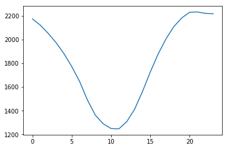

```python
plt.plot(wind_ave)
```

We can see pretty clearly that the min is 10 or 11...let's dig a little more.

One way to do this is to drop the data into a data frame and then *sort* the data frame.

```python
df_wind = pd.DataFrame(wind_ave)
df_wind
```

|  | MWh |
| --- | --- |
| 0 | 2173.268493 |
| 1 | 2120.778082 |
| 2 | 2051.832877 |
| 3 | 1973.969863 |
| 4 | 1881.463014 |
| 5 | 1772.484932 |
| 6 | 1646.630137 |
| 7 | 1490.194521 |
| 8 | 1363.402740 |
| 9 | 1290.512329 |
| 10 | 1250.408219 |
| 11 | 1247.643836 |
| 12 | 1308.287671 |
| 13 | 1412.410959 |
| 14 | 1561.602740 |
| 15 | 1726.652055 |
| 16 | 1878.441096 |
| 17 | 2005.934247 |
| 18 | 2109.093151 |
| 19 | 2181.361644 |
| 20 | 2229.408219 |
| 21 | 2231.687671 |
| 22 | 2220.109589 |
| 23 | 2216.526027 |

I'm going to be adding more MWh values to the data frame in just a moment, so let's be clear that this is the average

```python
df_wind.columns = ['Average MWh']
```

```python
df_wind.sort_values(by='Average MWh',ascending=True).head()
```

|  | Average MWh |
| --- | --- |
| 11 | 1247.643836 |
| 10 | 1250.408219 |
| 9 | 1290.512329 |
| 12 | 1308.287671 |
| 8 | 1363.402740 |

Ok -- so it looks as though mid-day is the minimum *average*.

But what's the range?

```python
wind_min = [] # initalizes a list to populate
wind_max = [] # initalizes a list to populate
for i in range(0,24):
    wind_min.append(np.min(wind.loc[windex.hour == i,:]))
    wind_max.append(np.max(wind.loc[windex.hour == i,:]))
```

```python
wind_max[0]
```

```
Source    WIND TOTAL
MWh             4795
dtype: object
```

```python
df_wind['min MWh']=pd.DataFrame(wind_min)['MWh']
df_wind['max MWh']=pd.DataFrame(wind_max)['MWh']
```

```python
df_wind
```

|  | Average MWh | min MWh | max MWh |
| --- | --- | --- | --- |
| 0 | 2173.268493 | 49 | 4795 |
| 1 | 2120.778082 | 33 | 4678 |
| 2 | 2051.832877 | 33 | 4696 |
| 3 | 1973.969863 | 36 | 4537 |
| 4 | 1881.463014 | 25 | 4377 |
| 5 | 1772.484932 | 17 | 4223 |
| 6 | 1646.630137 | 15 | 4161 |
| 7 | 1490.194521 | 29 | 3873 |
| 8 | 1363.402740 | 6 | 3905 |
| 9 | 1290.512329 | 10 | 3904 |
| 10 | 1250.408219 | 10 | 4518 |
| 11 | 1247.643836 | 8 | 4611 |
| 12 | 1308.287671 | 5 | 4561 |
| 13 | 1412.410959 | 0 | 4625 |
| 14 | 1561.602740 | 0 | 4876 |
| 15 | 1726.652055 | 0 | 4850 |
| 16 | 1878.441096 | 0 | 5006 |
| 17 | 2005.934247 | 0 | 4898 |
| 18 | 2109.093151 | 0 | 4925 |
| 19 | 2181.361644 | 2 | 4855 |
| 20 | 2229.408219 | 0 | 4953 |
| 21 | 2231.687671 | 0 | 4937 |
| 22 | 2220.109589 | 18 | 4887 |
| 23 | 2216.526027 | 62 | 4949 |

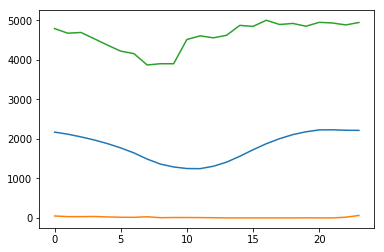

```python
plt.plot(df_wind)
```

### Challenge question: What *month* had the highest wind production in the last year?